# Infection and dislocation

Erik Bulow

2020-02-19

# 1 Note!

I will present both outcomes since it is easier for now. I will make separate figures and tables later for each publication separately.

# 2 Data

Linked data from:

- SHAR: THA-related
- Census (folkbokforing): death
- National Patient Register: co-morbidity
- LISA: education, civil status.
- Prescription register: ATC codes for Rx Risk V

# 3 Inclusion

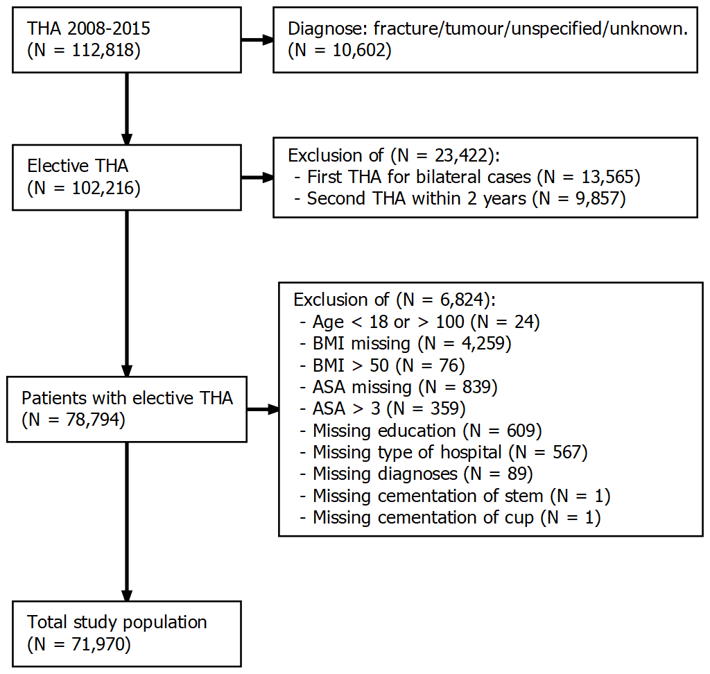

```r
knitr::include_graphics("../graphs/flowchart.png")
```

# 4 Comorbidity

- Charlson: 1 year prioir to surgery. ICD-10-codes as defined by Quan et al. (2005) with index weights by Charlson et al. (1987).
- Elixhauser: 1 year prioir to surgery. ICD-10-codes as defined by Quan et al. (2005) with unweighted sum as index.
- Rx Risk V: 1 year prioir to surgery. ATC-codes and index as defined by Pratt et al. (2018).

Individual groups from all above grouped as:

```r
load("../cache/tab_categorization.RData")
mutate_all(tab_categorization, coalesce, "")
```

| Comorbidities by groups | Charlson | Elixhauser | Rx |
| --- | --- | --- | --- |
| AIDS/HIV | Aids/hiv | Aids/hiv | Hiv |
| Allergies |  |  | Allergies |
| Anemia |  | Blood loss anemia, Deficiency anemia |  |
| Arrhythmia |  | Cardiac arrhythmias | Arrhythmia |
| Arterial hypertension |  | Hypertension uncomplicated, Hypertension complicated | Hypertension |
| Benign prostatic hyperplasia |  |  | Benign prostatic hyperplasia |
| Cancer | Malignancy, Metastatic solid tumor | Lymphoma, Metastatic cancer, Solid tumor | Malignancies |
| CNS disease | Dementia, Hemiplegia or paraplegia | Depression, Paralysis, Other neurological disorders, Psychoses | Dementia, Depression, Anxiety, Bipolar disorder, Epilepsy, Migraine, Parkinson s disease, Psychotic illness |
| Coagulopathy |  | Coagulopathy |  |
| Diabetes | Diabetes without complication, Diabetes complication | Diabetes uncomplicated, Diabetes complicated | Diabetes |
| Drug alcohol abuse |  | Alcohol abuse, Drug abuse | Alcohol dependence |
| Fluid electrolyte disorders |  | Fluid electrolyte disorders |  |
| Glaucoma |  |  | Glaucoma |
| Gout |  |  | Gout |
| Heart condition | Congestive heart failure | Congestive heart failure, Valvular disease | Congestive heart failure |
| Heart infarct | Myocardial infarction |  | Ischemic heart disease angina, Ischaemic heart disease hypertension |
| Hyperkalaemia |  |  | Hyperkalaemia |
| Hyperlipidaemia |  |  | Hyperlipidaemia |
| Hypothyroidism |  | Hypothyroidism | Hyperthyroidism |
| Kidney disease | Renal disease | Renal failure | Renal disease |
| Liver disease | Mild liver disease, Moderate or severe liver disease | Liver disease | Liver failure, Hepatitis c |
| Lung airways disease | Chronic pulmonary disease | Chronic pulmonary disease, Pulmonary circulation disorder | Smoking cessation, Chronic airways disease, Tuberculosis |
| Malnutrition |  |  | Malnutrition |
| Obesity |  | Obesity |  |
| Osteoporosis pagets |  |  | Osteoporosis paget s |
| Pain |  |  | Pain |
| Pancreatic insufficiency |  |  | Pancreatic insufficiency |
| Peptic ulcer | Peptic ulcer disease | Peptic ulcer disease | Gastrooesophageal reflux disease, Irritable bowel syndrome |
| Psoriasis |  |  | Psoriasis |
| Rheumatic disease | Rheumatic disease | Rheumatoid arthritis |  |
| Steroid responsive diseases |  |  | Steroid responsive disease |
| Transplant |  |  | Transplant |
| Vascular disease | Peripheral vascular disease, Cerebrovascular disease | Peripheral vascular disorder | Anticoagulants, Antiplatelets |
| Weight loss |  | Weight loss |  |

# 5 Outcomes

Infection and dislocation as identified at reoperation in SHAR or from later recordings in NPR (ICD-10 or KVA).

Within 2 years and 90 das.

# 6 Rare conditions

We only kept potential predictors with at least 10 patients with and without respective outcome. Dropped variables are listed in the table. Most conditions were dropped due to too few patients with the condition who experienced the event (“event_cond”). Some conditions were so rare that there was not enough patients even without the event (“no event_cond”).

```r
model_data %>%
  select(outcome, time, lgl) %>%
  unnest("lgl") %>%
  group_by(outcome) %>%
  mutate(time = replace(time, duplicated(time), "")) %>%
  ungroup() %>%
  mutate(outcome = replace(outcome, duplicated(outcome), ""))
```

| outcome | time | variable | event_cond | event_no_cond | no event_cond | no event_no_cond |
| --- | --- | --- | --- | --- | --- | --- |
| dislocation | 2y | c_coagulopathy | 6 | 1185 | 243 | 70536 |
|  |  | c_hyperkalaemia | 3 | 1188 | 57 | 70722 |
|  |  | c_malnutrition | 1 | 1190 | 5 | 70774 |
|  |  | c_pancreatic_insufficiency | 5 | 1186 | 203 | 70576 |
|  |  | c_weight_loss | 1 | 1190 | 57 | 70722 |
|  | 90d | c_coagulopathy | 5 | 852 | 244 | 70869 |
|  |  | c_hyperkalaemia | 1 | 856 | 59 | 71054 |
|  |  | c_malnutrition | 0 | 857 | 6 | 71107 |
|  |  | c_pancreatic_insufficiency | 2 | 855 | 206 | 70907 |
|  |  | c_psoriasis | 5 | 852 | 591 | 70522 |
|  |  | c_transplant | 5 | 852 | 193 | 70920 |
|  |  | c_weight_loss | 1 | 856 | 57 | 71056 |
| infection | 2y | c_anemia | 8 | 754 | 461 | 70747 |
|  |  | c_coagulopathy | 4 | 758 | 245 | 70963 |
|  |  | c_fluid_electrolyte_disorders | 8 | 754 | 412 | 70796 |
|  |  | c_hyperkalaemia | 2 | 760 | 58 | 71150 |
|  |  | c_malnutrition | 0 | 762 | 6 | 71202 |
|  |  | c_pancreatic_insufficiency | 5 | 757 | 203 | 71005 |
|  |  | c_transplant | 4 | 758 | 194 | 71014 |
|  |  | c_weight_loss | 1 | 761 | 57 | 71151 |
|  | 90d | c_aids_hiv | 7 | 560 | 1110 | 70293 |
|  |  | c_anemia | 6 | 561 | 463 | 70940 |
|  |  | c_coagulopathy | 4 | 563 | 245 | 71158 |
|  |  | c_fluid_electrolyte_disorders | 6 | 561 | 414 | 70989 |
|  |  | c_hyperkalaemia | 1 | 566 | 59 | 71344 |
|  |  | c_kidney_disease | 9 | 558 | 827 | 70576 |
|  |  | c_malnutrition | 0 | 567 | 6 | 71397 |
|  |  | c_pancreatic_insufficiency | 4 | 563 | 204 | 71199 |
|  |  | c_psoriasis | 9 | 558 | 587 | 70816 |
|  |  | c_transplant | 4 | 563 | 194 | 71209 |
|  |  | c_weight_loss | 1 | 566 | 57 | 71346 |

We did the same check for individual levels of categorical variables:

```r
model_data %>% select(outcome, time, fct)
```

| outcome | time | fct |
| --- | --- | --- |
| dislocation | 2y | NA |
| dislocation | 90d | NA |
| infection | 2y | NA |
| infection | 90d | P_DiaGrp != ‘Childhood disease’ |

Hence, patients with childhood disease were excluded for prediction of infection within 90 days. This, this model was trained on 70393 patients.

# 7 Summary tables

We make those for outcome within 2 years, but this could be modified!

## 7.1 Infection

```r
load("../cache/table1_infection.RData")
table1_infection$table1
```

| what | level | TRUE | FALSE | Total |
| --- | --- | --- | --- | --- |
| n |  | 762 | 71208 | 71970 |
| Age (mean (SD)) |  | 69.13 (11.30) | 67.82 (10.81) | 67.83 (10.81) |
| Sex = Female (%) |  | 323 (42.4) | 39910 (56.0) | 40233 (55.9) |
| BMI (mean (SD)) |  | 28.82 (5.17) | 27.13 (4.42) | 27.14 (4.43) |
| ASA class (%) |  |  |  |  |
|  | I | 115 (15.1) | 18038 (25.3) | 18153 (25.2) |
|  | II | 418 (54.9) | 41779 (58.7) | 42197 (58.6) |
|  | III | 229 (30.1) | 11391 (16.0) | 11620 (16.1) |
| Diagnos (%) |  |  |  |  |
|  | Primary osteoarthritis | 604 (79.3) | 62321 (87.5) | 62925 (87.4) |
|  | Secondary osteoarthritis | 30 ( 3.9) | 2253 ( 3.2) | 2283 ( 3.2) |
|  | Childhood disease | 11 ( 1.4) | 1566 ( 2.2) | 1577 ( 2.2) |
|  | Idiopathic necrosis | 29 ( 3.8) | 1587 ( 2.2) | 1616 ( 2.2) |
|  | Inflammatory joint disease | 17 ( 2.2) | 900 ( 1.3) | 917 ( 1.3) |
|  | Sequelae | 71 ( 9.3) | 2581 ( 3.6) | 2652 ( 3.7) |
| Cemented stem (%) |  | 524 (68.8) | 48206 (67.7) | 48730 (67.7) |
| Cemented cup (%) |  | 578 (75.9) | 55500 (77.9) | 56078 (77.9) |
| Hospital (%) |  |  |  |  |
|  | University | 246 (32.3) | 27188 (38.2) | 27434 (38.1) |
|  | County | 297 (39.0) | 23005 (32.3) | 23302 (32.4) |
|  | Rural | 134 (17.6) | 14676 (20.6) | 14810 (20.6) |
|  | Private | 85 (11.2) | 6339 ( 8.9) | 6424 ( 8.9) |
| Education (%) |  |  |  |  |
|  | Low | 158 (20.7) | 18527 (26.0) | 18685 (26.0) |
|  | Middle | 294 (38.6) | 23043 (32.4) | 23337 (32.4) |
|  | High | 310 (40.7) | 29638 (41.6) | 29948 (41.6) |
| Civil status (%) |  |  |  |  |
|  | Married | 392 (51.4) | 39669 (55.7) | 40061 (55.7) |
|  | Single | 250 (32.8) | 21084 (29.6) | 21334 (29.6) |
|  | Widow/widower | 120 (15.7) | 10455 (14.7) | 10575 (14.7) |
| Charlson (%) |  |  |  |  |
|  | 0 | 489 (64.2) | 54771 (76.9) | 55260 (76.8) |
|  | 1 | 153 (20.1) | 9725 (13.7) | 9878 (13.7) |
|  | 2 | 62 ( 8.1) | 4387 ( 6.2) | 4449 ( 6.2) |
|  | 3 | 27 ( 3.5) | 1360 ( 1.9) | 1387 ( 1.9) |
|  | 4+ | 31 ( 4.1) | 965 ( 1.4) | 996 ( 1.4) |
| Elixhauser (%) |  |  |  |  |
|  | 0 | 348 (45.7) | 41562 (58.4) | 41910 (58.2) |
|  | 1 | 190 (24.9) | 16633 (23.4) | 16823 (23.4) |
|  | 2 | 111 (14.6) | 8087 (11.4) | 8198 (11.4) |
|  | 3+ | 113 (14.8) | 4926 ( 6.9) | 5039 ( 7.0) |
| Rxriskv (mean (SD)) |  | 3.21 (3.27) | 2.12 (2.97) | 2.13 (2.98) |
| AIDS/HIV (%) |  | 10 ( 1.3) | 1107 ( 1.6) | 1117 ( 1.6) |
| Allergies (%) |  | 89 (11.7) | 6901 ( 9.7) | 6990 ( 9.7) |
| Anemia (%) |  | 8 ( 1.0) | 461 ( 0.6) | 469 ( 0.7) |
| Arrhythmia (%) |  | 82 (10.8) | 5088 ( 7.1) | 5170 ( 7.2) |
| Arterial hypertension (%) |  | 375 (49.2) | 29548 (41.5) | 29923 (41.6) |
| Benign prostatihyperplasia (%) |  | 46 ( 6.0) | 2719 ( 3.8) | 2765 ( 3.8) |
| Cancer (%) |  | 54 ( 7.1) | 3281 ( 4.6) | 3335 ( 4.6) |
| CNS disease (%) |  | 230 (30.2) | 14072 (19.8) | 14302 (19.9) |
| Coagulopathy (%) |  | 4 ( 0.5) | 245 ( 0.3) | 249 ( 0.3) |
| Diabetes (%) |  | 108 (14.2) | 6384 ( 9.0) | 6492 ( 9.0) |
| Drug alcohol abuse (%) |  | 20 ( 2.6) | 707 ( 1.0) | 727 ( 1.0) |
| Fluid electrolyte disorders (%) |  | 8 ( 1.0) | 412 ( 0.6) | 420 ( 0.6) |
| Glaucoma (%) |  | 42 ( 5.5) | 2970 ( 4.2) | 3012 ( 4.2) |
| Gout (%) |  | 35 ( 4.6) | 1579 ( 2.2) | 1614 ( 2.2) |
| Heart condition (%) |  | 302 (39.6) | 22450 (31.5) | 22752 (31.6) |
| Heart infarct (%) |  | 323 (42.4) | 24978 (35.1) | 25301 (35.2) |
| Hyperkalaemia (%) |  | 2 ( 0.3) | 58 ( 0.1) | 60 ( 0.1) |
| Hyperlipidaemia (%) |  | 187 (24.5) | 15946 (22.4) | 16133 (22.4) |
| Hypothyroidism (%) |  | 64 ( 8.4) | 6038 ( 8.5) | 6102 ( 8.5) |
| Kidney disease (%) |  | 13 ( 1.7) | 823 ( 1.2) | 836 ( 1.2) |
| Liver disease (%) |  | 69 ( 9.1) | 3396 ( 4.8) | 3465 ( 4.8) |
| Lung airways disease (%) |  | 82 (10.8) | 3954 ( 5.6) | 4036 ( 5.6) |
| Malnutrition (%) |  | 0 | 6 ( <0.1) | 6 ( 0.0) |
| Obesity (%) |  | 22 ( 2.9) | 1268 ( 1.8) | 1290 ( 1.8) |
| Osteoporosis pagets (%) |  | 43 ( 5.6) | 3138 ( 4.4) | 3181 ( 4.4) |
| Pain (%) |  | 413 (54.2) | 31490 (44.2) | 31903 (44.3) |
| Pancreatiinsufficiency (%) |  | 5 ( 0.7) | 203 ( 0.3) | 208 ( 0.3) |
| Peptiulcer (%) |  | 193 (25.3) | 16572 (23.3) | 16765 (23.3) |
| Psoriasis (%) |  | 14 ( 1.8) | 582 ( 0.8) | 596 ( 0.8) |
| Rheumatidisease (%) |  | 53 ( 7.0) | 2884 ( 4.1) | 2937 ( 4.1) |
| Steroid responsive diseases (%) |  | 101 (13.3) | 7<0.1 ( 9.9) | 7141 ( 9.9) |
| Transplant (%) |  | 4 ( 0.5) | 194 ( 0.3) | 198 ( 0.3) |
| Vascular disease (%) |  | 289 (37.9) | 19579 (27.5) | 19868 (27.6) |
| Weight loss (%) |  | 1 ( 0.1) | 57 ( 0.1) | 58 ( 0.1) |

## 7.2 Dislocation

```r
load("../cache/table1_dislocation.RData")
table1_dislocation$table1
```

| what | level | TRUE | FALSE | Total |
| --- | --- | --- | --- | --- |
| n |  | 1191 | 70779 | 71970 |
| Age (mean (SD)) |  | 69.96 (10.64) | 67.80 (10.81) | 67.83 (10.81) |
| Sex = Female (%) |  | 588 (49.4) | 39645 (56.0) | 40233 (55.9) |
| BMI (mean (SD)) |  | 27.49 (4.67) | 27.14 (4.43) | 27.14 (4.43) |
| ASA class (%) |  |  |  |  |
|  | I | 164 (13.8) | 17989 (25.4) | 18153 (25.2) |
|  | II | 730 (61.3) | 41467 (58.6) | 42197 (58.6) |
|  | III | 297 (24.9) | 11323 (16.0) | 11620 (16.1) |
| Diagnos (%) |  |  |  |  |
|  | Primary osteoarthritis | 939 (78.8) | 61986 (87.6) | 62925 (87.4) |
|  | Secondary osteoarthritis | 53 ( 4.5) | 2230 ( 3.2) | 2283 ( 3.2) |
|  | Childhood disease | 24 ( 2.0) | 1553 ( 2.2) | 1577 ( 2.2) |
|  | Idiopathic necrosis | 54 ( 4.5) | 1562 ( 2.2) | 1616 ( 2.2) |
|  | Inflammatory joint disease | 27 ( 2.3) | 890 ( 1.3) | 917 ( 1.3) |
|  | Sequelae | 94 ( 7.9) | 2558 ( 3.6) | 2652 ( 3.7) |
| Cemented stem (%) |  | 831 (69.8) | 47899 (67.7) | 48730 (67.7) |
| Cemented cup (%) |  | 890 (74.7) | 55188 (78.0) | 56078 (77.9) |
| Hospital (%) |  |  |  |  |
|  | University | 444 (37.3) | 26990 (38.1) | 27434 (38.1) |
|  | County | 404 (33.9) | 22898 (32.4) | 23302 (32.4) |
|  | Rural | 219 (18.4) | 14591 (20.6) | 14810 (20.6) |
|  | Private | 124 (10.4) | 6300 ( 8.9) | 6424 ( 8.9) |
| Education (%) |  |  |  |  |
|  | Low | 278 (23.3) | 18407 (26.0) | 18685 (26.0) |
|  | Middle | 414 (34.8) | 22923 (32.4) | 23337 (32.4) |
|  | High | 499 (41.9) | 29449 (41.6) | 29948 (41.6) |
| Civil status (%) |  |  |  |  |
|  | Married | 602 (50.5) | 39459 (55.7) | 40061 (55.7) |
|  | Single | 378 (31.7) | 20956 (29.6) | 21334 (29.6) |
|  | Widow/widower | 211 (17.7) | 10364 (14.6) | 10575 (14.7) |
| Charlson (%) |  |  |  |  |
|  | 0 | 790 (66.3) | 54470 (77.0) | 55260 (76.8) |
|  | 1 | 222 (18.6) | 9656 (13.6) | 9878 (13.7) |
|  | 2 | 107 ( 9.0) | 4342 ( 6.1) | 4449 ( 6.2) |
|  | 3 | 35 ( 2.9) | 1352 ( 1.9) | 1387 ( 1.9) |
|  | 4+ | 37 ( 3.1) | 959 ( 1.4) | 996 ( 1.4) |
| Elixhauser (%) |  |  |  |  |
|  | 0 | 538 (45.2) | 41372 (58.5) | 41910 (58.2) |
|  | 1 | 309 (25.9) | 16514 (23.3) | 16823 (23.4) |
|  | 2 | 188 (15.8) | 8<0.1 (11.3) | 8198 (11.4) |
|  | 3+ | 156 (13.1) | 4883 ( 6.9) | 5039 ( 7.0) |
| Rxriskv (mean (SD)) |  | 3.39 (3.46) | 2.11 (2.96) | 2.13 (2.98) |
| AIDS/HIV (%) |  | 22 ( 1.8) | 1095 ( 1.5) | 1117 ( 1.6) |
| Allergies (%) |  | 144 (12.1) | 6846 ( 9.7) | 6990 ( 9.7) |
| Anemia (%) |  | 17 ( 1.4) | 452 ( 0.6) | 469 ( 0.7) |
| Arrhythmia (%) |  | 117 ( 9.8) | 5053 ( 7.1) | 5170 ( 7.2) |
| Arterial hypertension (%) |  | 632 (53.1) | 29291 (41.4) | 29923 (41.6) |
| Benign prostatihyperplasia (%) |  | 68 ( 5.7) | 2697 ( 3.8) | 2765 ( 3.8) |
| Cancer (%) |  | 68 ( 5.7) | 3267 ( 4.6) | 3335 ( 4.6) |
| CNS disease (%) |  | 409 (34.3) | 13893 (19.6) | 14302 (19.9) |
| Coagulopathy (%) |  | 6 ( 0.5) | 243 ( 0.3) | 249 ( 0.3) |
| Diabetes (%) |  | 137 (11.5) | 6355 ( 9.0) | 6492 ( 9.0) |
| Drug alcohol abuse (%) |  | 37 ( 3.1) | 690 ( 1.0) | 727 ( 1.0) |
| Fluid electrolyte disorders (%) |  | 16 ( 1.3) | 404 ( 0.6) | 420 ( 0.6) |
| Glaucoma (%) |  | 59 ( 5.0) | 2953 ( 4.2) | 3012 ( 4.2) |
| Gout (%) |  | 59 ( 5.0) | 1555 ( 2.2) | 1614 ( 2.2) |
| Heart condition (%) |  | 490 (41.1) | 22262 (31.5) | 22752 (31.6) |
| Heart infarct (%) |  | 511 (42.9) | 24790 (35.0) | 25301 (35.2) |
| Hyperkalaemia (%) |  | 3 ( 0.3) | 57 ( 0.1) | 60 ( 0.1) |
| Hyperlipidaemia (%) |  | 301 (25.3) | 15832 (22.4) | 16133 (22.4) |
| Hypothyroidism (%) |  | 111 ( 9.3) | 5991 ( 8.5) | 6102 ( 8.5) |
| Kidney disease (%) |  | 33 ( 2.8) | 803 ( 1.1) | 836 ( 1.2) |
| Liver disease (%) |  | 98 ( 8.2) | 3367 ( 4.8) | 3465 ( 4.8) |
| Lung airways disease (%) |  | 92 ( 7.7) | 3944 ( 5.6) | 4036 ( 5.6) |
| Malnutrition (%) |  | 1 ( 0.1) | 5 ( <0.1) | 6 ( 0.0) |
| Obesity (%) |  | 32 ( 2.7) | 1258 ( 1.8) | 1290 ( 1.8) |
| Osteoporosis pagets (%) |  | 88 ( 7.4) | 3093 ( 4.4) | 3181 ( 4.4) |
| Pain (%) |  | 693 (58.2) | 31210 (44.1) | 31903 (44.3) |
| Pancreatiinsufficiency (%) |  | 5 ( 0.4) | 203 ( 0.3) | 208 ( 0.3) |
| Peptiulcer (%) |  | 360 (30.2) | 16405 (23.2) | 16765 (23.3) |
| Psoriasis (%) |  | 10 ( 0.8) | 586 ( 0.8) | 596 ( 0.8) |
| Rheumatidisease (%) |  | 100 ( 8.4) | 2837 ( 4.0) | 2937 ( 4.1) |
| Steroid responsive diseases (%) |  | 195 (16.4) | 6946 ( 9.8) | 7141 ( 9.9) |
| Transplant (%) |  | 11 ( 0.9) | 187 ( 0.3) | 198 ( 0.3) |
| Vascular disease (%) |  | 442 (37.1) | 19426 (27.4) | 19868 (27.6) |
| Weight loss (%) |  | 1 ( 0.1) | 57 ( 0.1) | 58 ( 0.1) |

# 8 Models

The variable selection process is rerun 100 times. Some variables are always included (n = 100), some are less common.

```r
model_data %>%
  select(outcome, time, coefs_selected) %>%
  mutate(coefs_selected = map(coefs_selected, "brlasso_tbl_selected")) %>%
  unnest("coefs_selected") %>%
  group_by(outcome) %>%
  mutate(time = replace(time, duplicated(time), "")) %>%
  ungroup() %>%
  mutate(outcome = replace(outcome, duplicated(outcome), ""))
```

| outcome | time | variable | n |
| --- | --- | --- | --- |
| dislocation | 2y | c_psoriasis_TRUE. | 100 |
|  |  | P_DiaGrp_Idiopathic.necrosis | 100 |
|  |  | P_DiaGrp_Inflammatory.joint.disease | 100 |
|  |  | P_DiaGrp_Sequelae | 100 |
|  |  | P_Sex_Female | 100 |
|  |  | c_drug_alcohol_abuse_TRUE. | 96 |
|  |  | c_cns_disease_TRUE. | 46 |
|  |  | c_cancer_TRUE. | 26 |
|  |  | P_BMI | 5 |
|  | 90d | c_psoriasis_TRUE. | 100 |
|  |  | P_DiaGrp_Idiopathic.necrosis | 100 |
|  |  | P_DiaGrp_Inflammatory.joint.disease | 100 |
|  |  | P_DiaGrp_Sequelae | 100 |
|  |  | P_Sex_Female | 100 |
|  |  | c_drug_alcohol_abuse_TRUE. | 95 |
|  |  | c_cns_disease_TRUE. | 45 |
|  |  | c_cancer_TRUE. | 25 |
|  |  | c_rheumatic_disease_TRUE. | 1 |
|  |  | P_BMI | 1 |
| infection | 2y | c_psoriasis_TRUE. | 100 |
|  |  | P_DiaGrp_Idiopathic.necrosis | 100 |
|  |  | P_DiaGrp_Inflammatory.joint.disease | 100 |
|  |  | P_DiaGrp_Sequelae | 100 |
|  |  | P_Sex_Female | 100 |
|  |  | c_drug_alcohol_abuse_TRUE. | 95 |
|  |  | c_cns_disease_TRUE. | 43 |
|  |  | c_cancer_TRUE. | 31 |
|  |  | P_BMI | 2 |
|  |  | c_rheumatic_disease_TRUE. | 1 |
|  | 90d | c_psoriasis_TRUE. | 100 |
|  |  | P_DiaGrp_Idiopathic.necrosis | 100 |
|  |  | P_DiaGrp_Inflammatory.joint.disease | 100 |
|  |  | P_DiaGrp_Sequelae | 100 |
|  |  | P_Sex_Female | 100 |
|  |  | c_drug_alcohol_abuse_TRUE. | 94 |
|  |  | c_cns_disease_TRUE. | 42 |
|  |  | c_cancer_TRUE. | 24 |
|  |  | P_BMI | 3 |

We use all variables for the “main models” but only variables selected at least 75 times out of 100 are included in the reduced models.

It might be relevant however to decrease the cut-of to a lower number, perhaps 20? The reason is that the full model is superior to the reduced model but that it feels a little unnecessary to include variables that were seldom selected.

# 9 Internal validation

## 9.1 ROC-curves

We can see that the main model with age as RCS is superioir for all outcomes, although the main model with age as a main effect is not far behind for infection within 2 years.

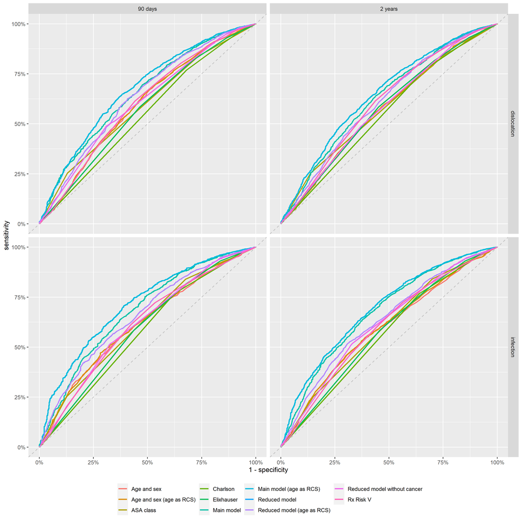

```r
knitr::include_graphics("../graphs/roc.png")
```

## 9.2 AUC

Unfourtenately, no model had AUC above 0.7. The main models seem preferable although the added value of age as RCS is not significant. Main effects model might be preffered due to simplicity?

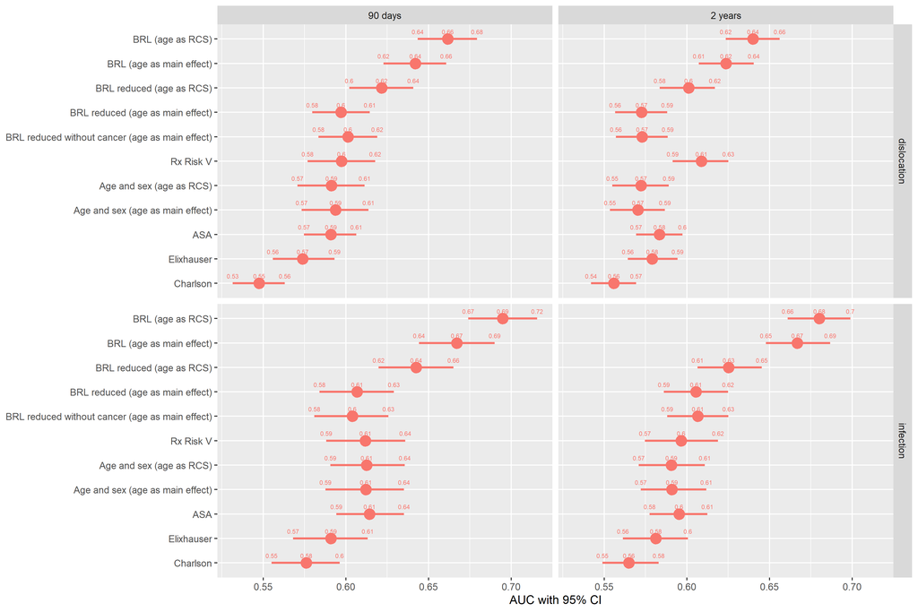

```r
knitr::include_graphics("../graphs/auc_ci.png")
```

## 9.3 Separation

There is not much separation between patients with and without each outcome (main models with age as main effect).

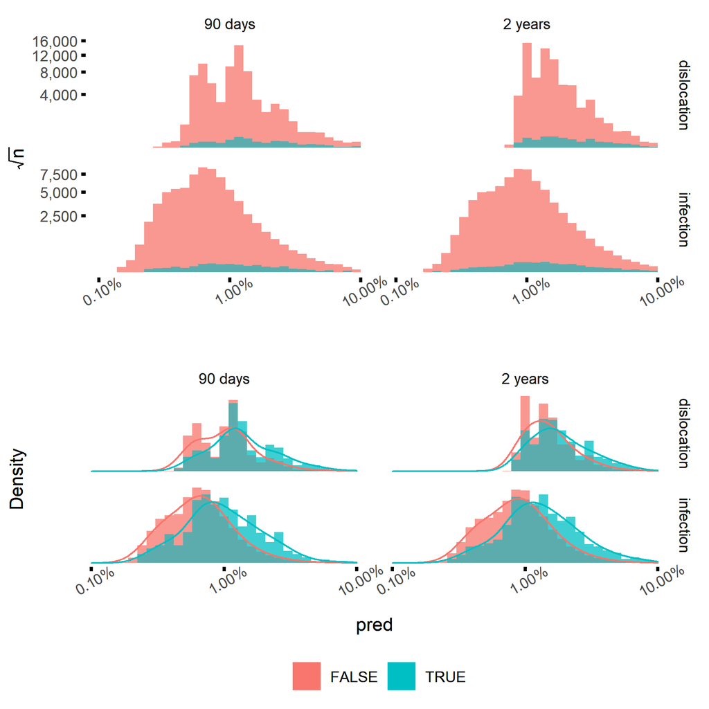

```r
knitr::include_graphics("../graphs/separation.png")
```

## 9.4 Calibration

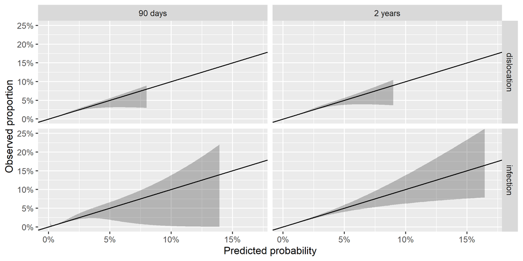

```r
knitr::include_graphics("../graphs/calibration.png")
```

# 10 Model parameters

Note that we have here included all levels from variables included with any level in the models. Hence all diagnoses, although some are not differnet from baseline. This should probably be changed to another baseline and without “others” etc. After that, we might merge some of the levels etc.

I include all models here since they can be looked at separately (compared to the graphs which would be very messy).

```r
load("../cache/tbl_coefs.RData")

tbl_coefs %>%
  select(-Model, -math) %>%
  group_by(outcome) %>%
  mutate(time = replace(as.character(time), duplicated(time), "")) %>%
  ungroup() %>%
  mutate(
    outcome = replace(outcome, duplicated(outcome), ""),
    beta = round(beta, 2)
  )
```

| outcome | time | term | beta | OR 95 % CI | p |
| --- | --- | --- | --- | --- | --- |
| dislocation | 2 years | (intercept) | -4.82 |  |  |
|  |  | Psoriasis | -0.12 | 0.89 (0.44-1.57) | 0.71 |
|  |  | Diagnos: secondary osteoarthritis | 0.40 | 1.49 (1.11-1.95) | <0.01 |
|  |  | Diagnos: childhood disease | 0.05 | 1.05 (0.68-1.54) | 0.82 |
|  |  | Diagnos: idiopathic necrosis | 0.70 | 2.02 (1.50-2.65) | <0.01 |
|  |  | Diagnos: inflammatory joint disease | 0.76 | 2.15 (1.42-3.11) | <0.01 |
|  |  | Diagnos: sequelae | 0.75 | 2.11 (1.68-2.62) | <0.01 |
|  |  | Sexfemale | -0.36 | 0.70 (0.62-0.78) | <0.01 |
|  |  | Drug alcohol abuse | 0.62 | 1.86 (1.29-2.59) | <0.01 |
|  |  | CNS disease | 0.74 | 2.10 (1.85-2.38) | <0.01 |
|  |  | Cancer | 0.11 | 1.11 (0.86-1.42) | 0.40 |
|  |  | BMI | 0.02 | 1.02 (1.01-1.04) | <0.01 |
|  | 90 days | (intercept) | -5.39 |  |  |
|  |  | Psoriasis | -0.46 | 0.63 (0.22-1.37) | 0.30 |
|  |  | Diagnos: secondary osteoarthritis | 0.36 | 1.43 (1.01-1.97) | 0.03 |
|  |  | Diagnos: childhood disease | 0.28 | 1.32 (0.82-1.99) | 0.22 |
|  |  | Diagnos: idiopathic necrosis | 0.82 | 2.27 (1.64-3.07) | <0.01 |
|  |  | Diagnos: inflammatory joint disease | 0.09 | 1.09 (0.60-1.87) | 0.76 |
|  |  | Diagnos: sequelae | 0.88 | 2.41 (1.86-3.09) | <0.01 |
|  |  | Sexfemale | -0.60 | 0.55 (0.48-0.63) | <0.01 |
|  |  | Drug alcohol abuse | 0.65 | 1.92 (1.27-2.79) | <0.01 |
|  |  | CNS disease | 0.69 | 2.00 (1.72-2.32) | <0.01 |
|  |  | Cancer | 0.18 | 1.20 (0.90-1.57) | 0.20 |
|  |  | Rheumatidisease | 0.63 | 1.87 (1.38-2.48) | <0.01 |
|  |  | BMI | 0.03 | 1.03 (1.02-1.05) | <0.01 |
| infection | 2 years | (intercept) | -6.89 |  |  |
|  |  | Psoriasis | 0.68 | 1.97 (1.09-3.24) | 0.01 |
|  |  | Diagnos: secondary osteoarthritis | 0.25 | 1.29 (0.87-1.83) | 0.18 |
|  |  | Diagnos: childhood disease | -0.27 | 0.77 (0.40-1.33) | 0.38 |
|  |  | Diagnos: idiopathic necrosis | 0.54 | 1.72 (1.15-2.47) | <0.01 |
|  |  | Diagnos: inflammatory joint disease | 0.36 | 1.44 (0.81-2.43) | 0.19 |
|  |  | Diagnos: sequelae | 1.13 | 3.10 (2.37-3.99) | <0.01 |
|  |  | Sexfemale | -0.63 | 0.53 (0.46-0.62) | <0.01 |
|  |  | Drug alcohol abuse | 0.43 | 1.54 (0.94-2.39) | 0.07 |
|  |  | CNS disease | 0.56 | 1.75 (1.48-2.05) | <0.01 |
|  |  | Cancer | 0.35 | 1.42 (1.06-1.86) | 0.02 |
|  |  | BMI | 0.08 | 1.09 (1.07-1.10) | <0.01 |
|  |  | Rheumatidisease | 0.58 | 1.78 (1.28-2.42) | <0.01 |
|  | 90 days | (intercept) | -7.14 |  |  |
|  |  | Psoriasis | 0.51 | 1.67 (0.79-3.06) | 0.13 |
|  |  | Diagnos: secondary osteoarthritis | 0.23 | 1.26 (0.78-1.90) | 0.31 |
|  |  | Diagnos: childhood disease | -0.16 | 0.85 (0.40-1.55) | 0.63 |
|  |  | Diagnos: idiopathic necrosis | 0.69 | 2.00 (1.28-2.97) | <0.01 |
|  |  | Diagnos: inflammatory joint disease | 0.57 | 1.76 (0.87-3.14) | 0.08 |
|  |  | Diagnos: sequelae | 1.29 | 3.64 (2.72-4.80) | <0.01 |
|  |  | Sexfemale | -0.58 | 0.56 (0.47-0.66) | <0.01 |
|  |  | Drug alcohol abuse | 0.51 | 1.67 (0.97-2.69) | 0.05 |
|  |  | CNS disease | 0.58 | 1.78 (1.47-2.14) | <0.01 |
|  |  | Cancer | 0.25 | 1.28 (0.90-1.77) | 0.15 |
|  |  | BMI | 0.08 | 1.09 (1.07-1.10) | <0.01 |

# Bibliography

Charlson, Mary E., Peter Pompei, Kathy L. Ales, and C. Ronald MacKenzie. 1987. “A New Method of Classifying Prognostic Comorbidity in Longitudinal Studies: Development and Validation.” *Journal of Chronic Diseases* 40 (5): 373–83. https://doi.org/10.1016/0021-9681(87)90171-8.

Pratt, Nicole L., Mhairi Kerr, John D. Barratt, Anna Kemp-Casey, Lisa M. Kalisch Ellett, Emmae Ramsay, and Elizabeth Ellen Roughead. 2018. “The Validity of the Rx-Risk Comorbidity Index Using Medicines Mapped to the Anatomical Therapeutic Chemical (ATC) Classification System.” *BMJ Open* 8 (4). https://doi.org/10.1136/bmjopen-2017-021122.

Quan, Hude, Vijaya Sundararajan, Patricia Halfon, Andrew Fong, Bernard Burnand, Jean-Christophe Luthi, L Duncan Saunders, Cynthia a Beck, Thomas E Feasby, and William a Ghali. 2005. “Coding Algorithms for Defining Comorbidities in ICD-9-CM and ICD-10 Administrative Data.” *Medical Care* 43 (11): 1130–9. https://doi.org/10.1097/01.mlr.0000182534.19832.83.